# training

## 1) Importing libraries

```python
import polars as pl

from sklearn.metrics import f1_score, accuracy_score, recall_score, log_loss
from sklearn.model_selection import train_test_split, GridSearchCV

from sklearn.pipeline import Pipeline

from sklearn.tree import DecisionTreeClassifier, ExtraTreeClassifier
from sklearn.ensemble import RandomForestClassifier
from sklearn.linear_model import RidgeClassifier
from sklearn.naive_bayes import GaussianNB
from sklearn.svm import SVC
from sklearn.neighbors import KNeighborsClassifier
from sklearn.neural_network import MLPClassifier

import matplotlib.pyplot as plt
import seaborn as sns

from functions import plots
from pathlib import Path

import joblib

from time import time
```

## 2) Reading dataset

```python
random_state = 1
primary_color = "#1c3148"
secondary_color = "#c56715"
```

### 2.1) Importing cleaned data

```python
dataset = pl.read_parquet(
    source = "./dataset/cleaned_dataset.parquet",
)

print(dataset.shape)
dataset.head(2)
```

```
(520, 15)
```

shape: (2, 15)

| age i8 | polyuria bool | polydipsia bool | sudden_weight_loss bool | weakness bool | polyphagia bool | genital_thrush bool | visual_blurring bool | itching bool | delayed_healing bool | partial_paresis bool | muscle_stiffness bool | alopecia bool | obesity bool | class bool |
| --- | --- | --- | --- | --- | --- | --- | --- | --- | --- | --- | --- | --- | --- | --- |
| 40 | false | true | false | true | false | false | false | true | true | false | true | true | true | true |
| 58 | false | false | false | true | false | false | true | false | false | true | false | true | false | true |

## 3) Preparing data

### 3.1) Splinting the data

Here, we are going to split the data into train and test samples in order to evaluate all sorts of models.

```python
dataset = dataset.to_pandas()

X_train, X_test, y_train, y_test = train_test_split(
    dataset.drop("class", axis = 1), dataset["class"],
    test_size = 0.2,
    random_state = random_state,
    stratify = dataset["class"]
)

print(
    X_train.shape, X_test.shape, y_train.shape, y_test.shape
)
```

```
(416, 14) (104, 14) (416,) (104,)
```

## 4) Training

### 4.1) Setting algorithms

The following code is just a simple list of models with all sorts of paramns. These paramns are here because they are going to help us to find the best hiperparamns for each model - given us the true potential of each training set.

```python
models = [

    {
        "name": "GaussianNB",
        "model": GaussianNB(),
        "paramns": {
            "model__var_smoothing": [1E-5, 1E-6, 1E-7, 1E-8, 1E-9, 1E-10, 1E-11],
        },
        "x_train": X_train,
        "y_train": y_train
    },

    {
        "name": "RidgeClassifier",
        "model": RidgeClassifier(),
        "paramns": {
            "model__alpha": [.1, 0.25, 0.5, 0.75, 1, 1.5, 2, 5],
            "model__solver": ['auto', 'svd', 'cholesky', 'lsqr', 'sparse_cg', 'sag', 'saga'],
        },
        "x_train": X_train,
        "y_train": y_train
    },

    {
        "name": "RandomForestClassifier",
        "model": RandomForestClassifier(),
        "paramns": {
            "model__n_estimators": [10, 25, 50, 100, 150, 200, 250],
            "model__max_features": ['sqrt', 'log2'],
            "model__criterion": ['gini', 'entropy', 'log_loss'],
            "model__class_weight": ['balanced', None],
        },
        "x_train": X_train,
        "y_train": y_train
    },

    {
        "name": "DecisionTreeClassifier",
        "model": DecisionTreeClassifier(),
        "paramns": {
            "model__criterion": ['gini', 'entropy', 'log_loss'],
            "model__class_weight": ['balanced', None],
        },
        "x_train": X_train,
        "y_train": y_train
    },

    {
        "name": "ExtraTreeClassifier",
        "model": ExtraTreeClassifier(),
        "paramns": {
            "model__criterion": ['gini', 'entropy', 'log_loss'],
            "model__class_weight": ['balanced', None],
        },
        "x_train": X_train,
        "y_train": y_train
    },

    {
        "name": "SVC",
        "model": SVC(),
        "paramns": {
            "model__C": [0.01, 0.05, 0.1, 0.2, 0.3, 0.4, 0.5, 0.6, 0.7, 0.8, 0.9, 1, 1.5, 2],
            "model__kernel": ['linear', 'poly', 'rbf', 'sigmoid'],
            "model__class_weight": ['balanced', None]
        },
        "x_train": X_train,
        "y_train": y_train
    },

    {
        "name": "KNeighborsClassifier",
        "model": KNeighborsClassifier(),
        "paramns": {
            "model__n_neighbors": [5, 10, 15, 20],
            "model__weights": ['uniform', 'distance'],
            "model__p": [1, 2]
        },
        "x_train": X_train,
        "y_train": y_train
    },

    {
        "name": "MLPClassifier",
        "model": MLPClassifier(max_iter = 200, tol = 0.001),
        "paramns": {
            "model__hidden_layer_sizes": [
                (32, 32, 32, ),
                (32, 32, 16, ),
                (32, 32, 8, ),
                (32, 16, 16, ),
                (32, 16, 8, ),
                (32, 8, 8, ),
                (16, 16, 16, ),
                (16, 16, 8, ),
                (16, 8, 8, ),
                (8, 8, 8, ),
                (32, 32, ),
                (16, 16, ),
                (8, 8, ),
                (32, ),
                (16, ),
                (8, ),
            ],
            "model__activation": ['relu', 'tanh'],
            "model__batch_size": [8, 16, 32],
        },
        "x_train": X_train,
        "y_train": y_train
    },
]
```

### 4.2) GridSearch

We train our models here.

```python
pre_processing = joblib.load(
    filename = "./models/preprocessing/pre_processing.joblib"
)

for model in models:

    pipeline = Pipeline(
        steps = [
            ("pre_processing", pre_processing),
            ("model", model["model"])
        ]
    )

    estimator = GridSearchCV(
        estimator = pipeline,
        param_grid = model["paramns"],
        n_jobs = -1,
        cv = 5,
        error_score = "raise",
        scoring = "f1",
        refit = True
    )

    estimator.fit(
        X = model['x_train'],
        y = model['y_train']
    )

    joblib.dump(
        filename = f"./models/tests/{model['name']}.joblib",
        value = estimator.best_estimator_
    )
```

## 5) Evaluating

### 5.1) Confusion matrices

For each trained model, we are going to test them using our test dataset create early. To evaluate their precision, we are going to use a confusion matrix display in order to see false positives and negatives.

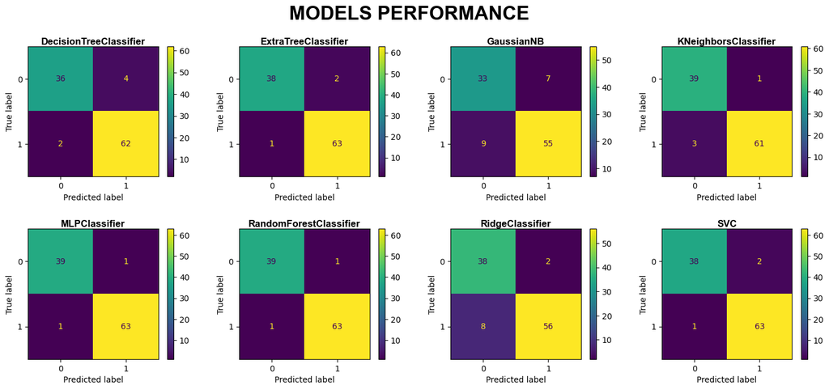

```python
trained_models = []

for archive in Path("./models/tests/").iterdir():

    trained_models.append(
        {
            "name": archive.name.replace(".joblib", ""),
            "model": joblib.load(
                filename = archive
            )
        }
    )

fig, axs = plt.subplots(
    ncols = 4,
    nrows = 2,
    figsize = (18, 7),
    gridspec_kw = {
        "hspace": 0.4
    }
)

axs = axs.flatten()

metrics = {
    "model": [],
    "f1": [],
    "accuracy": [],
    "recall": [],
    "log_loss": [],
    "time": []
}

for index, model in enumerate(trained_models):

    start_time = time()
    prediction = model["model"].predict(
        X = X_test
    )
    end_time = time()

    metrics["model"].append(model["name"])
    metrics["time"].append(end_time - start_time)
    metrics["f1"].append(
        f1_score(
            y_true = y_test,
            y_pred = prediction
        )
    )
    metrics["accuracy"].append(
        accuracy_score(
            y_true = y_test,
            y_pred = prediction
        )
    )
    metrics["recall"].append(
        recall_score(
            y_true = y_test,
            y_pred = prediction
        )
    )
    metrics["log_loss"].append(
        log_loss(
            y_true = y_test,
            y_pred = prediction
        )
    )

    plots.plot_confusion_matrix(
        ax = axs[index],
        y_true = y_test,
        y_pred = prediction,
        title = {
            "text": model["name"]
        }
    )

plt.suptitle(
    t = "MODELS PERFORMANCE",
    fontsize = 24,
    fontweight = "bold",
    fontfamily = "arial"
)
plt.show()
```

### 5.2) Overall metrics

#### 5.2.1) Creating dataset

Here is our overall performance for each model. Knowing that high `f1`, `accuracy` and `recall` scores means that our model - on simple terms - are performing well, we decided that `time` and `log_loss` should have at negative weights, since they are variables that fight against our model performance.

```python
metrics_df = pl.DataFrame(
    metrics
)

metrics_df = metrics_df.with_columns(
    (
        pl.col("f1")*0.5 + pl.col("accuracy") + 0.5*pl.col("recall") - pl.col("log_loss") - pl.col("time")
    ).alias("overall")
).sort(
    by = "overall",
    descending = True
)

metrics_df
```

shape: (8, 7)

| model str | f1 f64 | accuracy f64 | recall f64 | log_loss f64 | time f64 | overall f64 |
| --- | --- | --- | --- | --- | --- | --- |
| "RandomForestClassifier" | 0.984375 | 0.980769 | 0.984375 | 0.693147 | 0.00061 | 1.271387 |
| "MLPClassifier" | 0.984375 | 0.980769 | 0.984375 | 0.693147 | 0.016668 | 1.255329 |
| "SVC" | 0.976744 | 0.971154 | 0.984375 | 1.039721 | 0.0 | 0.911993 |
| "ExtraTreeClassifier" | 0.976744 | 0.971154 | 0.984375 | 1.039721 | 0.011833 | 0.90016 |
| "KNeighborsClassifier" | 0.968254 | 0.961538 | 0.953125 | 1.386294 | 0.0 | 0.535934 |
| "DecisionTreeClassifier" | 0.953846 | 0.942308 | 0.96875 | 2.079442 | 0.0 | -0.175836 |
| "RidgeClassifier" | 0.918033 | 0.903846 | 0.875 | 3.465736 | 0.018351 | -1.683725 |
| "GaussianNB" | 0.873016 | 0.846154 | 0.859375 | 5.545177 | 0.0 | -3.832828 |

#### 5.2.2) Plots

Here is the overall model performance plot.

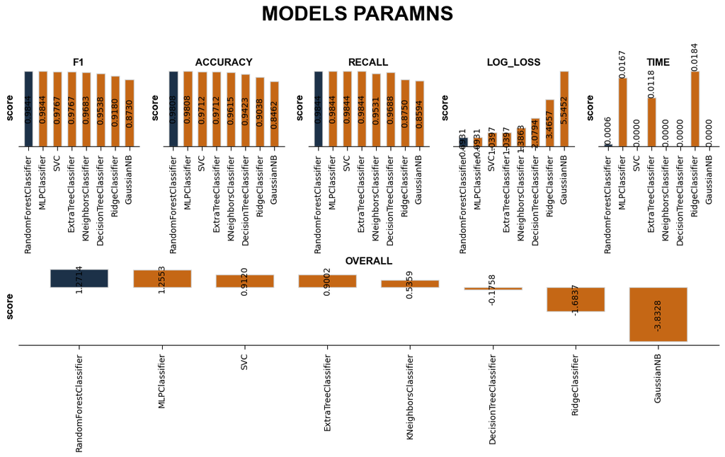

```python
columns = ["f1", "accuracy", "recall", "log_loss", "time"]

fig, axs = plt.subplot_mosaic(
    mosaic = [columns, ["overall", "overall", "overall", "overall", "overall"]],
    figsize = (15, 6),
    gridspec_kw = {
        "hspace": 1.5
    }
)


for index, column in enumerate(columns):

    plots.plot_bar(
        ax = axs[column],
        x_values = metrics_df["model"],
        y_values = metrics_df[column],
        colors = [primary_color] + [secondary_color]*15,
        legends = column,
        title = {
            "text": column.upper()
        },
        x_label = {
            "text": "",
        },
        y_label = {
            "text": "score"
        },
        width = 0.6,
        tooltip_rotation = 90,
        tooltip_align = ["center", "center", "center", "center", "edge"][index],
        formater = "{:,.4f}",
    )

    axs[column].tick_params(axis='x', labelrotation = 90, size = 5)

plots.plot_bar(
    ax = axs["overall"],
    x_values = metrics_df["model"],
    y_values = metrics_df["overall"],
    colors = [primary_color, secondary_color, secondary_color, secondary_color, secondary_color, secondary_color, secondary_color, secondary_color, secondary_color],
    legends = "overall",
    title = {
        "text": "overall".upper()
    },
    x_label = {
        "text": "",
    },
    y_label = {
        "text": "score"
    },
    width = 0.7,
    tooltip_rotation = 90,
    tooltip_align = "center",
    formater = "{:,.4f}",
)
axs["overall"].tick_params(axis='x', labelrotation = 90, size = 5)

plt.suptitle(
    t = "MODELS PARAMNS",
    fontsize = 24,
    y = 1.05,
    fontweight = "bold",
    fontfamily = "arial"
)

plt.show()
```

## 6) Choosing model

Here, we are going to save our best model to use in production.

```python
best_model = joblib.load(
    filename = f"./models/tests/{metrics_df[0,0]}.joblib"
)

joblib.dump(
    value = best_model,
    filename = "./models/pipeline/diabetes_model.joblib"
)
```

```
['./models/pipeline/diabetes_model.joblib']
```

```python
best_model
```

```
Pipeline(steps=[('pre_processing',
                 ColumnTransformer(remainder='passthrough',
                                   transformers=[('pca', PCA(n_components=1),
                                                  ['polyuria', 'polydipsia']),
                                                 ('age_encoder',
                                                  StandardScaler(),
                                                  ['age'])])),
                ('model',
                 RandomForestClassifier(class_weight='balanced',
                                        criterion='entropy'))])
```